# ISA 616 Final Project

Andrew Edwards, Nick Oakley, and Lauren Pagel

2024-12-05

# **Problem Statement**

The ISA department has multiple classes of students each year. However, each year the number of students who graduate as seniors with their undergraduate does not align with the number of students in the major the previous year. Our primary goal with this project is to restructure and classify the students in a way that the department can accurately anticipate for the correct number of graduates the year before. Secondly, along with graduation, we have been asked to research the data and understand where these students are going, what are the leading causes of students leaving, and to redesign the classification metrics for grade level.

# **Research Questions**

- What is the best way to classify student grade levels? Number of credit hours? Full semesters at Miami?
- Why are there fewer graduating seniors than estimated each year, and what is the cause for this drop-off?
  - Where are these students going?
- Are there indicators that can show when we estimate a student is about to graduate? We can look at number of credit hours, semesters at Miami, course performance and more.

# **Business Value Proposition**

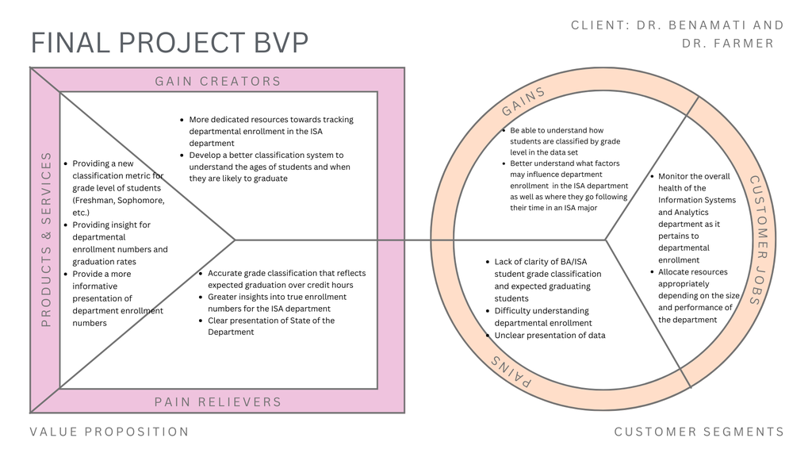

## Customer Jobs

Our client for this project is the Information Systems and Analytics department at Miami, but more specifically, Dr. Benamati and Dr. Farmer. These two have a very important role in the ISA department to monitor the health of the organization and to appropriate allocate resources based on needs.

### Monitor the Overall Health of the Information Systems and Analytics Department as it Pertains to Departmental Entrollment

As the chairs of the department, Dr. Benamati and Dr. Farmer are tasked with monitoring the overall health and performance of the Information Systems and Analytics department. This can include monitoring departmental enrollment as it pertains to showing the amount of students who enter into ISA majors as freshmen, retention within the department, and ultimately, how many students graduate with a degree from the department. This health ultimately helps Dr. Benamati and Dr. Farmer argue for the case of the ISA department during the State of the Department and can help the department grow over time.

### Allocate Resources Appropriately Depending on the Size and Performance of the Department

Based on the health that is monitored from the department, Dr. Benamati and Dr. Farmer are tasked with allocating resources appropriately. This can include increasing the number of professors or course sections offered depending on the amount of ISA majors that are enrolled.

## Customer Pains

### Lack of Clarity of BA/ISA Student Grade Classification and Expected Graduating Students

Student classification of grades has led to inaccurate data regarding the number of expected graduates.

### Difficulty Understanding Departmental Enrollment

Due to misclassifications and other factors, there are inaccuracies that misrepresent the true enrollment of the ISA department

### Unclear Presentation of Data

The current table that is used to present enrollment data can be confusing and inaccurate.

## Customer Gains

### Be Able to Understand How Students are Classified as Freshmen, Sophomores, etc. in the Data Set

With the current data set, the current classification of grades has led to inaccurate data reporting when it comes to anticipating the number of graduates within the data set.

### Better Understand what Factors May Influence Departmental Enrollment in the ISA Department as Well as Where they Go if they Change their Major

Within the current data set, there is no way to estimate when a student is about to exit the ISA department, whether that be because they are about to graduate or because they are changing their major. Thus, it makes it difficult for the ISA department to allocate their resources to maximize student benefit.

## Products and Services

### Providing a New Classification Metric for Grade Level of Students (Freshman, Sophomore, etc.)

Take more factors into account to better determine expected graduation of students. Current method of classification by number of credit hours does not best reflect student year and expected graduation.

### Providing Insight for Departmental Enrollment Numbers and Graduation Rates

Better indicate when a student is about to graduate from the ISA department so that resources can be allocated effectively.

### Providing a More Informative Presentation of Department Enrollment Numbers

The current matrix visual within the State of the Department Presentation can be hard for a non-analytical audience to read to understand the enrollment numbers problem easily.

## Pain Relievers

### Accurate Grade Classification that Reflects Expected Graduation

With the current state of the data, the actual number of graduating seniors is less than the anticipated amount in the previous year. Through our work, we seek to relieve this pain to account for anticipated early graduations, transfers, etc. We also seek to find a better way to classify student grades rather than solely by number of credit hours taken.

### Greater Insights Into True Enrollment Numbers for the ISA Department

Through our solution, we will provide the ISA department with a more accurate reporting for the ISA department so that they are able to allocate resources and budget effectively for the upcoming year.

### Clear Presentation of the State of the Department

Through our solution, we will prepare a more effective presentation of the ISA department’s numbers in the State of the Department presentation. This information will be well organized in a way that those who do not have a strong background in analytics are still able to obtain valuable insights.

## Gain Creators

Our solution will give the ISA department the information they need to better plan for the upcoming year by providing estimates of the number of students that will come through the department and eventually graduate each year. This will allow both Dr. Benamati and Dr. Farmer to spend less time on this administrative task and instead on preparing for the longevity of the department.

### Better Classification System to Understand the Ages of Students and When They Are Likely to Graduate

Our solution will provide the ISA department with a better system to classify students by their grade level so they can better understand and predict the number of students who will graduate from the department.

# **Timeline for Completion**

1. Draft of Problem Statement - Due with checkpoint 1 materials on November 4th. Responsible stakeholder: Nick Oakley.
2. Develop Research Questions - Due with checkpoint 1 materials on November 4th. Responsible stakeholder: Andrew Edwards.
3. Business Value Propositions - Due with checkpoint 1 materials on November 4th. Responsible stakeholder: Lauren Pagel.
4. Upload Data into Document - Do by the EOD on November 5th after class. Responsible stakeholder: Andrew Edwards, Nick Oakley, Lauren Pagel.
5. Clean Dataset - Work on in class on November 5th and 7th, finish by November 10th. Responsible stakeholder: Andrew Edwards, Nick Oakley, Lauren Pagel.
6. Merge Datasets Together - Turned in with Project #2 Checkpoint on 11/17. Responsible stakeholder: Andrew Edwards, Nick Oakley, Lauren Pagel.
7. Develop Metric to Count the Number of Students for Each Grade Level - Work on during class on 11/19 and 11/21. Responsible stakeholder: Andrew Edwards, Nick Oakley, Lauren Pagel.
8. Begin Building Visualizations - Build out by the end of the week on 11/22. Responsible stakeholder: Andrew Edwards, Nick Oakley, Lauren Pagel.
9. Draft of Final Presentation Slides - Have draft done by 11/26 before Thanksgiving Break. Responsible stakeholder: Andrew Edwards, Nick Oakley, Lauren Pagel.
10. Draft Technical Report - Have draft done by 11/26 before Thanksgiving Break. Responsible stakeholder: Andrew Edwards, Nick Oakley, Lauren Pagel.
11. Revise Technical Report - Finish revisions by 12/3. Responsible stakeholder: Andrew Edwards, Nick Oakley, Lauren Pagel.
12. Revise Final Presentation Slides - Finish revisions by 12/3. Responsible stakeholder: Andrew Edwards, Nick Oakley, Lauren Pagel.
13. Submit Final Slides and Technical Report - Submit by EOD December 5th. Responsible stakeholder: Andrew Edwards, Nick Oakley, Lauren Pagel.
14. Deliver Final Presentation - Present week of December 3rd. Responsible stakeholder: Andrew Edwards, Nick Oakley, Lauren Pagel.

# **Deliverables**

## Full Technical Report

This report will be submitted by 11:59pm on December 5th. This report will detail information about our data, cleaning process, results, and limitations of the data. The goal of this report is to explain our processes in a way that provides explicit clarity and resembles the characteristics of a reproducible data analysis.

## Presentation Slides

Another aspect of our project that we will deliver are our presentation slides, as well as our presentation. These will also be due by 11:59pm on December 5th, although our presentation may fall earlier. The goal of this presentation is to clearly articulate our findings to our audience and visualize the data in a way that is easy for someone with a non-technical background to understand.

## Reproducible Data Analysis

Along with our technical report and presentation, we will also submit a fully reproducible data analysis. This is so that as more students come through the department, this analysis will be able to rerun for new sets of students.

# **Analysis**

## **BA Majors**

### Counts of BA Students Across Cohort and Term Code

To begin our analysis, I am interested in looking at the raw counts of students enrolled in the BA major across different cohort terms and term codes in which they are enrolled at Miami. This code will filter my table for students who have BA Major indicated for at least one of their majors across different semesters for students in a particular cohort term. Below is our code output. Moving forward with analysis, I would be interested in showing how the number of students who graduated each semester could be implemented with this as we work to reclassify students. In addition, numbers from this table could be used to track student movement through various majors, should they change their major away from Business Analytics.

```
## # A tibble: 76 × 3
##    Cohort.Term Term.Code Num_Students
##          <int>     <int>        <int>
##  1      201510    201520            2
##  2      201510    201610            2
##  3      201510    201620            2
##  4      201510    201710            2
##  5      201510    201720            2
##  6      201510    201810            2
##  7      201510    201820            2
##  8      201610    201710            1
##  9      201610    201720            2
## 10      201610    201810            2
## # ℹ 66 more rows
```

### Graduation Counts for BA Majors by Academic Year

To provide ourselves with a good baseline before doing any further analysis, we want to generate an overarching graph that shows the number of students who have graduated for each academic year:

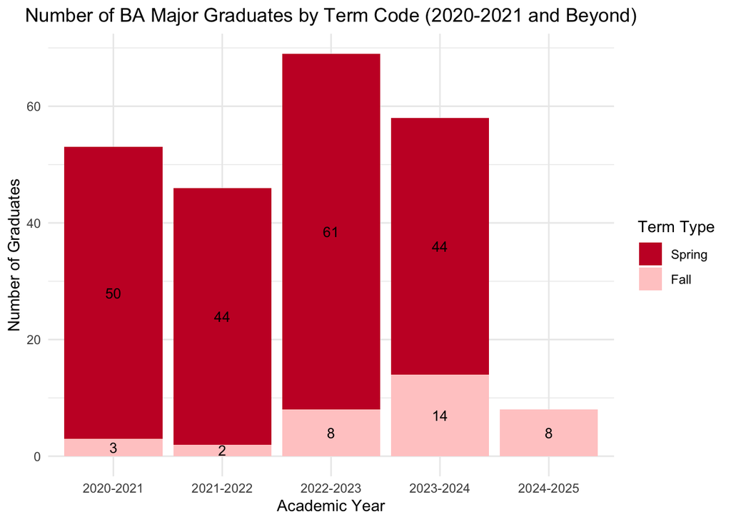

### Graduation Counts for BA Majors - by Cohort and Term Code

This preliminary analysis shows the number of students from each cohort term who graduated each semester. From first looks, I notice that most students graduate during the spring of their senior year. This table, with the knowledge of the data we have, also indicates that there tends to be relatively few exceptions to this rule - as a significantly smaller number of students ten to graduate during the fall term, and few also graduate a full year early or late than their peers in their cohort term.

```
## # A tibble: 24 × 3
##    Cohort.Term Term.Code Num_Graduated
##          <int>     <int>         <int>
##  1      201510    201820             2
##  2      201610    201920             2
##  3      201810    202020             2
##  4      201810    202110             3
##  5      201810    202120            49
##  6      201810    202210             2
##  7      201810    202310             1
##  8      201910    202120             1
##  9      201910    202220            40
## 10      201910    202310             5
## # ℹ 14 more rows
```

As our first classification method, we want to explore classifying students by the number of semesters they have been enrolled at Miami University. To start, I want to show the incoming pipeline numbers for students in the Business Analytics Major in Fall 2023. These students will be classified by the number of semesters they have completed, which is defined as:

- A student who has completed 0 or 1 semesters will be a freshman
- A student who has completed 2 or 3 semesters will be a sophomore
- A student who has completed 4 or 5 semesters will be a junior
- A student who has completed 6 or 7 semesters will be a senior
- A student who has previously completed 8+ semesters will be classified as a super-senior

Student Classification for Fall 2023

| Term Code | Classification | Number of Students |
| --- | --- | --- |
| 202410 | Freshmen | 110 |
| 202410 | Sophomore | 99 |
| 202410 | Junior | 89 |
| 202410 | Senior | 58 |
| 202410 | Super Senior | 3 |

As we can see, this number of incoming seniors closely aligns with the number of students we saw graduate with a BA degree at the end of the 2023-2024 school year.

Let’s more closely take a look at those who graduated last year:

Graduates by Number of Semesters for Academic Year 2023-2024

| Number of Semesters | Number of Graduates |
| --- | --- |
| 6 | 1 |
| 7 | 11 |
| 8 | 43 |
| 9 | 1 |
| 10 | 2 |

Out of the 58 business analytics graduates we had for the academic year 2023-2024, we can see that many of them graduated over a wide variety of semesters. Many students were able to complete the degree in 7 semesters, perhaps explaining the winter graduate number. However, we are still able to see that the overwhelming majority of students in 2023-2024 graduated with a degree in Business Analytics following their 8th semester.

To validate this assumption, let’s show the distribution of number of semesters it takes for students to graduate:

Distribution of Semesters to Graduation

| Number of Semesters | Number of Students | % of Total |
| --- | --- | --- |
| 4 | 1 | 0.3367003 |
| 6 | 14 | 4.7138047 |
| 7 | 30 | 10.1010101 |
| 8 | 238 | 80.1346801 |
| 9 | 9 | 3.0303030 |
| 10 | 5 | 1.6835017 |

With the current distribution of values within our data set, I can see that 80.13% of graduated students with a major in Business Analytics took 8 semesters to complete their degree. The next closest percentage is 7 semesters, which comes in around 10.10%. While there are certainly cases of students taking more or less time to graduate with their degree, the distribution of this data set leads me to believe that we should proceed by classifying student grade levels based upon the number of semesters of enrollment.

### Count of Student Grade Classification by Credit Hours

Before we examine the possibility of classifying students as per the number of semesters they have completed at Miami, let’s first take a look into our data to see what the distribution of the number of credit hours students complete when they graduate.

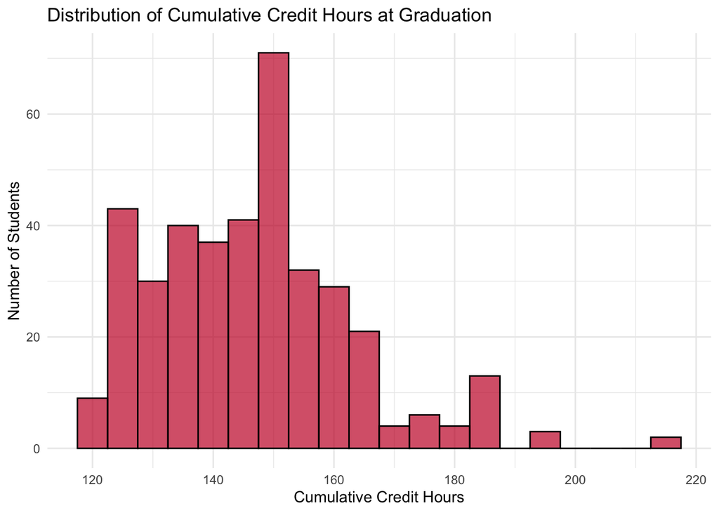

As shown by this graph, students will graduate from Miami University with a wide variety of cumulative credit hours completed. This data could somewhat be impacted by how many transfer credits that a student has from high school, their number of majors and minors, and potentially if they want to be CPA eligible. Below we will detail some further statistics regarding those in our data set who have graduated with a Business Analytics Degree.

Graduated Students’ Cumulative Credit Hours Statistics

| Minimum Credit Hours | Mean Credit Hours | Maximum Credit Hours |
| --- | --- | --- |
| 120 | 146.7247 | 213 |

Cumulative Credit Hours Statistics for First Term

| min_credit_hrs | median_credit_hrs | max_credit_hrs |
| --- | --- | --- |
| 0 | 29 | 133 |

Mean Credit Hours by Number of Majors for Graduated Students

| Number of Majors | Mean Credit Hours |
| --- | --- |
| 1 | 135.6413 |
| 2 | 152.3896 |
| 3 | 179.8000 |

To proceed, we will explore the possibility of classifying students by the number of credit hours they have completed.

In our previous analyses, we were exploring the potential of classifying students in our database based upon the number of semesters they have been enrolled at Miami University. However, another potential area we may explore to classify students is based on the number of cumulative credit hours they have completed, whether at Miami University or elsewhere. Many students may have transfer credits through AP coursework from high school or from another college if they transferred. We suspect that BannerWeb is currently classifying students based on the number of cumulative credit hours they have completed currently, but have no inclination if that is true.

```
## # A tibble: 63 × 3
## # Groups:   Term.Code [20]
##    Term.Code Classification Num_Students
##        <int> <chr>                 <int>
##  1    201520 Junior                    1
##  2    201520 Senior                    1
##  3    201610 Senior                    2
##  4    201620 Senior                    2
##  5    201710 Senior                    3
##  6    201720 Senior                    4
##  7    201810 Freshman                  4
##  8    201810 Junior                    1
##  9    201810 Senior                    4
## 10    201810 Sophomore                 5
## # ℹ 53 more rows
```

I operationally defined a student’s credit hour intake as follows:

- If a student is in their first semester they are automatically classified as a freshman.
- If a student has between 0-30 credit hours, they are classified as a freshman.
- If a student has between 30-60 credit hours, they are classified as a sophomore.
- If a student has between 60-90 credit hours, they are classified as a junior.
- If a student has 90+ credit hours, they are classified as a senior.

When I classify a student’s grade classification, assuming that on average each student completes 15 credit hours per semester, I start to notice a couple of problems. For starters, let’s examine the incoming pipeline number for last fall:

Pipeline Numbers for 2023-2024

| Term Code | Classification | Number of Students |
| --- | --- | --- |
| 202410 | Freshmen | 119 |
| 202410 | Sophomore | 68 |
| 202410 | Junior | 81 |
| 202410 | Senior | 91 |

As I look at this data, I see that my incoming pipeline numbers for seniors do not come close to matching the number of seniors who graduated in the academic year 2023-2024. From this, we are able to make two key conclusions:

1. The number of cumulative credit hours a student has completed does not reflect their status to graduate.
2. While coming in with transfer credits is certainly beneficial for students, it is not always beneficial in helping them fill requirements for their particular degree program, which ultimately dictates their timeline to graduate.

### Cases of Students Graduating Early

From initially looking at the data, it appears that classifying students by the number of semesters they have completed is the most reliable. We want to start looking into the exceptions of the rule that students would graduate either earlier or later than their anticipated graduation date, or after 8 semesters they have completed at Miami University.

Let’s start by looking at the overall breakdown of these students who have graduated early with a Business Analytics major.

Distribution of Semesters to Graduation for BA Majors

| Number of Semesters | Number of Students | % of Total |
| --- | --- | --- |
| 4 | 1 | 2.12766 |
| 6 | 14 | 29.78723 |
| 7 | 32 | 68.08511 |

Let’s start by closely examining the factors that may have led to a student graduating in just four semesters.

Distribution of Semesters to Graduation

| Student.ID | Cohort.Term | Term.Code | Major.1 | Cum.Credit.Hrs | Cum.UG.Crs.GPA |
| --- | --- | --- | --- | --- | --- |
| 8231106 | 202210 | 202210 | BA Major | 79 | 3.58 |
| 8231106 | 202210 | 202220 | BA Major | 98 | 3.70 |
| 8231106 | 202210 | 202310 | BA Major | 111 | 3.76 |
| 8231106 | 202210 | 202320 | BA Major | 124 | 3.75 |

As I look through the four semesters of this student’s enrollment, the primary thing that jumps out at me is the number of cumulative credit hours that the student had completed their first semester. Having such a high number likely indicates that they either transferred a lot of credit from high school, or that they transferred to Miami from another school. This is a pattern we should continue to look at as we continue to develop our student classification mechanism further, as students with a high number of credit hours their first semester may be more likely to graduate early.

Let’s look at student’s who graduated in 6 semesters:

Distribution of Semesters to Graduation

| Student ID | Cohort Term | Term Code | Cumulative Credit Hours | Cumulative GPA | Major(s) |
| --- | --- | --- | --- | --- | --- |
| 8183549 | 202210 | 202210 | 47.0 | 3.92 | Human Capital Mgmt& Leadership |
| 8191653 | 202210 | 202210 | 65.0 | 3.72 | BA Major |
| 8191653 | 202210 | 202420 | 148.0 | 3.78 | BA Major |
| 8203607 | 202210 | 202210 | 15.0 | 3.67 | BA Major |
| 8203607 | 202210 | 202420 | 95.0 | 3.62 | BA Major |
| 8246520 | 202110 | 202110 | 69.0 | 3.49 | Finance |
| 8246520 | 202110 | 202320 | 151.0 | 3.36 | BA Major |
| 8264603 | 202010 | 202010 | 56.0 | 3.66 | Finance |
| 8264603 | 202010 | 202220 | 156.0 | 3.38 | BA Major, Finance |
| 8285262 | 202010 | 202010 | 133.0 | 3.84 | Finance |
| 8285262 | 202010 | 202220 | 213.0 | 3.97 | BA Major, Finance |
| 8291591 | 202010 | 202010 | 42.0 | 3.70 | Finance |
| 8291591 | 202010 | 202220 | 125.0 | 3.35 | BA Major |
| 8305468 | 202010 | 202010 | 64.0 | 4.00 | CAS |
| 8305468 | 202010 | 202220 | 139.0 | 3.95 | BA Major |
| 8335143 | 201910 | 201910 | 70.0 | 3.75 | BA Major, CAS |
| 8335143 | 201910 | 202120 | 179.0 | 3.74 | BA Major, CAS |
| 8359870 | 201810 | 201810 | 32.0 | 3.76 | Accountancy |
| 8359870 | 201810 | 202020 | 138.0 | 3.28 | Accountancy, BA Major |
| 8429284 | 201810 | 201810 | 62.5 | 3.27 | CAS |
| 8429284 | 201810 | 202020 | 151.5 | 3.20 | BA Major, CAS |

Above is the table showing the stats for students who graduated from Miami University in just 6 semesters with a degree in Business Analytics. Let’s summarize some of this detail at a high level:

Summary of Student Graduation Data

| Mean First Semester Credits | Mean Graduation GPA | Percentage with More Than One Major |
| --- | --- | --- |
| 59.59091 | 3.595455 | 45.45455 |

At a high level, the only item that sticks out is the average number of credit hours completed in the first semester. This number seems to be particularly higher amongst students who have graduated in both 4 and 6 semesters. Following the traditional college schedule of taking 15 credit hours per semester, we do not expect students to hit 60 credit hours until the end of their sophomore years. Thus, as we explore additional methods to classify students with grade levels, we should consider flagging these students who may have the potential to complete their degrees earlier than anticipated.

Another factor we want to examine is how many credit hours these students are taking per semester. Students who may be taking more credit hours may be on track to graduate earlier.

Aggregated Average Credit Hours per Semester for Graduated Students

| Average Credit Hours per Semester |
| --- |
| 16.41146 |

From this, I can see that students who are graduating in 6 semesters are taking on average, 16.41 credit hours per semester. This is above the 15 credit hour standard that is asked of students, implying that part of the reason these students may be in a position to graduate early is because they are taking more credit hours than the average student. The average credit hour intake for all students is shown below:

Aggregated Average Credit Hours per Semester for All Students

| Average Credit Hours per Semester |
| --- |
| 13.63535 |

### Cases of Students Graduating Late

Now that we have examined factors into students who have graduated sooner than 8 semesters, we also want to consider the possibility that a student would take longer than 8 semesters to graduate. Let’s show the distribution of students who have taken longer than 8 semesters to graduate:

Distribution of Semesters to Graduation for BA Majors

| Number of Semesters | Number of Students | % of Total |
| --- | --- | --- |
| 9 | 13 | 65 |
| 10 | 7 | 35 |

Out of students who are graduating late, it appears that it takes them no longer than 10 semesters to complete their degree. Let’s start by drilling into students who took 9 semesters to obtain a degree in Business Analytics.

Distribution of Semesters to Graduation

| Student ID | Cohort Term | Term Code | Cumulative Credit Hours | Cumulative GPA | Major(s) |
| --- | --- | --- | --- | --- | --- |
| 8277469 | 202010 | 202010 | 14 | 2.28 | Business Economics |
| 8277469 | 202010 | 202410 | 126 | 2.41 | BA Major |
| 8309126 | 201910 | 201910 | 12 | 2.75 | Marketing |
| 8309126 | 201910 | 202310 | 162 | 3.11 | BA Major, Marketing |
| 8315620 | 201910 | 201910 | 19 | 2.23 | Finance |
| 8315620 | 201910 | 202310 | 125 | 2.36 | BA Major |
| 8317414 | 201910 | 201910 | 12 | 2.49 | CAS, Supply Chain & Operations Mgmt |
| 8317414 | 201910 | 202310 | 147 | 2.58 | BA Major, Supply Chain & Operations Mgmt |
| 8332921 | 201910 | 201910 | 14 | 2.91 | Accountancy |
| 8332921 | 201910 | 202310 | 151 | 3.35 | Accountancy, BA Major |
| 8350888 | 201910 | 201910 | 21 | 3.22 | Business Economics |
| 8350888 | 201910 | 202310 | 146 | 2.69 | BA Major |
| 8383906 | 201810 | 201810 | 39 | 3.86 | Accountancy |
| 8383906 | 201810 | 202210 | 155 | 3.80 | Accountancy, BA Major |
| 8384659 | 201810 | 201810 | 16 | 2.84 | Business Economics |
| 8384659 | 201810 | 202210 | 136 | 2.88 | BA Major |
| 8386377 | 201810 | 201810 | 30 | 3.42 | Supply Chain & Operations Mgmt |
| 8386377 | 201810 | 202210 | 128 | 2.42 | BA Major |

This table shows the details for both a student’s first and last semester assuming they graduated in 9 semesters. Here are some of the high level statistics:

Summary of Student Graduation Data

| Mean First Semester Credits | Mean Graduation GPA | Percentage with More Than One Major |
| --- | --- | --- |
| 19.66667 | 2.844444 | 44.44444 |

This table confirms some of our initial assumptions about students who take longer than 8 semesters to graduate. Not shockingly, we see that these students often have significantly less credit hours after their first semester at Miami University. In addition we see that these students have a much lower GPA than students who graduate early. Let’s check the average graduation GPA to see if this differs significantly.

Average GPA for Students Graduated with BA Major

| Average GPA |
| --- |
| 3.43234 |

This table above confirms our general assumption that students who are graduating in more than 8 semesters have a lower GPA than the student body in general. These students also maybe have taken gap semesters or have failed classes, which they have had to retake. Let’s look at the average number of credit hours these students are taking per semester.

Aggregated Average Credit Hours per Semester for Graduated Students

| Average Credit Hours per Semester |
| --- |
| 11.53968 |

This data confirms our assumption that students who have graduated in 9 semesters have taken less of a credit hour load than the normal student body. The average amount of credit hours that students are completing on a semesterly basis may be something for the ISA department to consider as they track student progress, and potentially try and flag students who are falling behind.

Now that we have closely examined students who have graduated in 9 semesters, let’s see if this pattern is still true for students who have graduated in 10 semesters.

Distribution of Semesters to Graduation

| Student ID | Cohort Term | Term Code | Cumulative Credit Hours | Cumulative GPA | Major(s) |
| --- | --- | --- | --- | --- | --- |
| 8281767 | 202010 | 202010 | 26 | 2.95 | Business Economics |
| 8281767 | 202010 | 202420 | 134 | 2.76 | BA Major |
| 8305176 | 202010 | 202010 | 18 | 3.78 | Finance |
| 8305176 | 202010 | 202420 | 151 | 2.86 | BA Major |
| 8325151 | 201910 | 201910 | 34 | 3.53 | CAS |
| 8325151 | 201910 | 202320 | 165 | 3.48 | BA Major |
| 8339022 | 201910 | 201910 | 14 | 4.00 | CAS |
| 8339022 | 201910 | 202320 | 193 | 3.36 | BA Major, CCA, Supply Chain & Operations Mgmt |
| 8369044 | 201810 | 201810 | 24 | 2.51 | Undeclared - Business |
| 8369044 | 201810 | 202310 | 137 | 2.26 | BA Major |

Let’s look at some of these factors on a higher level:

Summary of Student Graduation Data

| Mean First Semester Credits | Mean Graduation GPA | Percentage with More Than One Major |
| --- | --- | --- |
| 23.2 | 2.944 | 40 |

Similarly to the students who graduated with a Business Analytics major in 9 semesters, those who graduated in 10 semesters have a lower cumulative GPA and less credit hours when they first start at Miami.

Let’s see if the number of credit hours they are taking per semester has an impact on their graduation.

Aggregated Average Credit Hours per Semester for Graduated Students

| Average Credit Hours per Semester |
| --- |
| 11.14286 |

Similarly to students who graduated in 9 semesters, students who took 10 semesters to graduate have less average credit hours per semester than an average Business Analytics graduate.

From our analyses of students who have graduated behind schedule, we have three major takeaways for the ISA department to potentially consider as they flag students who may be falling behind in the program:

1. Cumulative GPA - Students who may be at risk for graduating later than their peers may be doing so because they failed a core class that they would have to retake. The ISA department should consider flagging students with a cumulative GPA under a 3.0 during their time at Miami, as these students are at a significantly higher risk of graduating later than their peers in the program.
2. Number of Credit Hours Taken per Semester - This may coincide with GPA, as a student will not get credit for a class if they do not pass it. However, the department should be closely monitoring these numbers to identify students who may be at risk of completing their Business Analytics degree late. Miami University considers a full time student to be one that takes 12 credit hours per semester, so students taking an average less than that may be on a path to fall behind.
3. Changing Majors - The department also has data to track a student’s progress through their time at Miami. Although this may not be as significant of a factor as GPA or Credit Hours, the department should consider closely watching students who change their major, particularly between academic divisions. These students will likely have an increased number of requirements asked of them because of the change, and when they change their major should also be considered as students who change their major later in their academic career will be less likely to finish on time.

### Overall Findings for BA Majors

To summarize, we have found that classification by number of semesters completed appears to be the most accurate method. Thus, we will add a column to our dataset to keep track of student classification as they progress through their time at Miami.

```
## # A tibble: 6 × 14
##       X Student.ID Cohort.Term Term.Code Major.1  Major.2 Major.3
##   <int>      <int>       <int>     <int> <chr>    <chr>   <chr>
## 1     1    8023864      202510    202510 BA Major None    None
## 2     2    8024720      202510    202510 BA Major None    None
## 3     3    8026176      202510    202510 BA Major None    None
## 4     4    8031298      202510    202510 BA Major None    None
## 5     5    8034088      202510    202510 BA Major None    None
## 6     6    8035324      202510    202510 BA Major None    None
## # ℹ 7 more variables: Term.Code.Graduated <int>, Cum.Credit.Hrs <dbl>,
## #   Cum.UG.Crs.GPA <dbl>, max_term_code <int>, graduated <lgl>,
## #   Semesters_Completed <dbl>, Classification <fct>
```

## **IS Majors**

After performing all of these calculations and transformations on the BA dataset, we can now replicate the same actions for the IS dataset. That way, we can gather the same information and insights for these students, while also keeping the majors separate. This is important because these two majors have different numbers regarding enrollment, expected graduations, and credit hours. Also by keeping the datasets separate, it will be easier for the ISA department to target specific factors for each major, and determine new courses of action that may need to occur in order to encourage stronger academic development for that specific major.

All of the calculations below are ran to support our analyses and decisions made from the BA dataset. Many of the charts and metrics further support the same direction from BA students, while other calculations have a different direction, but still support the overall idea.

### Counts of IS Students Across Cohort and Term Code

We will begin our analysis by creating a general table of all IS students across each cohort and term code. For the sake of our analysis, all Cybersecurity Management majors will be grouped in with the Information Systems Majors.

```
## # A tibble: 53 × 3
##    Cohort.Term Term.Code Num_Students
##          <int>     <int>        <int>
##  1      201810    201810            5
##  2      201810    201820            7
##  3      201810    201910           23
##  4      201810    201920           35
##  5      201810    202010           40
##  6      201810    202020           41
##  7      201810    202110           42
##  8      201810    202120           41
##  9      201810    202210            2
## 10      201810    202220            2
## # ℹ 43 more rows
```

### Graduation Counts for IS Majors by Academic Year

Similarly to what we did for Business Analytics majors, we will start by showing the number of IS and Cybersecurity graduates across each academic year, which will serve as the basis for the rest of our analysis.

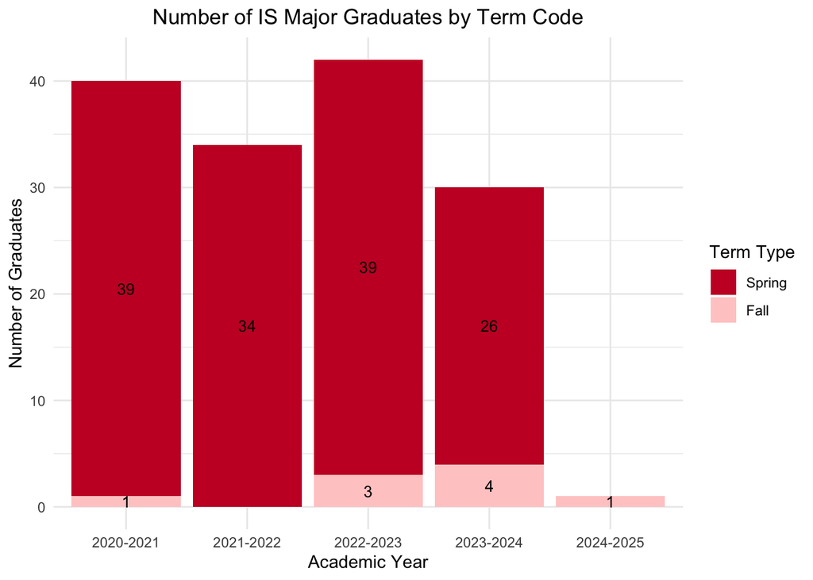

As we can see, the IS data set is significantly smaller than the BA dataset due to less students enrolled in the major.

We will continue our analysis of the Information Systems Majors by attempting to classify these students by both credit hours and number of semesters completed.

### Graduation Counts for IS Majors - by Cohort and Term Code

We will first try to group graduates across each term code by their cohort term.

```
## # A tibble: 15 × 3
##    Cohort.Term Term.Code Num_Graduated
##          <int>     <int>         <int>
##  1      201810    202110             1
##  2      201810    202120            38
##  3      201810    202220             1
##  4      201910    202120             1
##  5      201910    202220            31
##  6      201910    202320             1
##  7      202010    202220             2
##  8      202010    202310             3
##  9      202010    202320            37
## 10      202010    202410             1
## 11      202010    202420             2
## 12      202110    202320             1
## 13      202110    202410             3
## 14      202110    202420            24
## 15      202210    202510             1
```

- A student who has completed 0 or 1 semesters will be a freshman
- A student who has completed 2 or 3 semesters will be a sophomore
- A student who has completed 4 or 5 semesters will be a junior
- A student who has completed 6 or 7 semesters will be a senior
- A student who has previously completed 8+ semesters will be classified as a super-senior

Student Classification for Fall 2023

| Term Code | Classification | Number of Students |
| --- | --- | --- |
| 202410 | Freshmen | 7 |
| 202410 | Sophomore | 8 |
| 202410 | Junior | 29 |
| 202410 | Senior | 29 |
| 202410 | Super Senior | 1 |

Let’s more closely take a look at those who graduated last year:

Graduates by Number of Semesters for Academic Year 2023-2024

| Number of Semesters | Number of Graduates |
| --- | --- |
| 7 | 3 |
| 8 | 25 |
| 9 | 2 |

As shown by this table, the vast majority of my IS graduates last year completed their degree in 8 semesters, with a few exceptions. Let’s see if this rule holds true for other academic years in our database.

Let’s show the distribution of number of semesters it takes for students to graduate:

Distribution of Semesters to Graduation

| Number of Semesters | Number of Students | % of Total |
| --- | --- | --- |
| 6 | 4 | 2.2471910 |
| 7 | 15 | 8.4269663 |
| 8 | 155 | 87.0786517 |
| 9 | 3 | 1.6853933 |
| 10 | 1 | 0.5617978 |

As verified by this table, I see that a good chunk of my majority (87%) of all IS and Cybersecurity Management students graduate in 8 semesters. This remains consistent with my analysis of Business Analytics, and, barring any drastic discoveries in my credit hours columns, we should be good to proceed by classifying by the number of semesters.

### Count of Student Grade Classification by Credit Hours

Before we examine the possibility of classifying students as per the number of semesters they have completed at Miami, let’s first take a look into our data to see what the distribution of the number of credit hours students complete when they graduate.

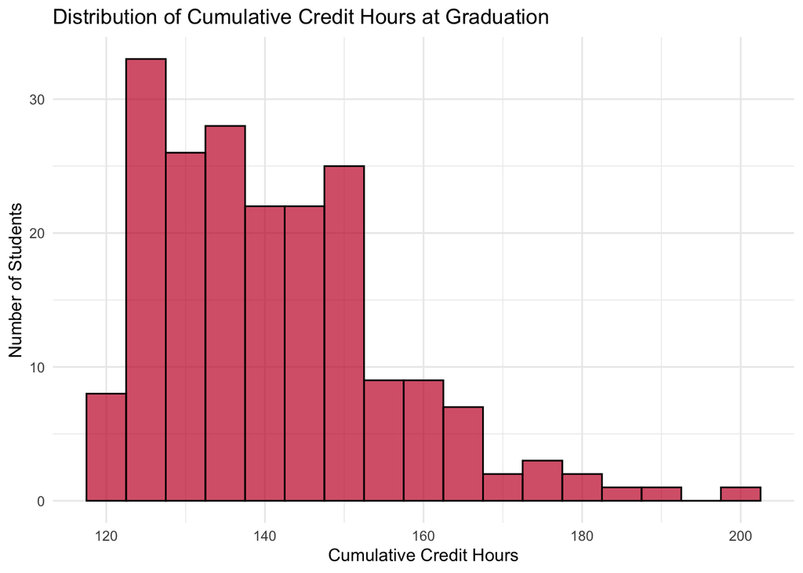

As shown by this graph, students will graduate from Miami University with a wide variety of cumulative credit hours completed. This data could somewhat be impacted by how many transfer credits that a student has from high school, their number of majors and minors, and potentially if they want to be CPA eligible. Below we will detail some further statistics regarding those in our data set who have graduated with an Information Systems Degree.

Below we will detail some further statistics regarding those in our data set who have graduated with an Information Systems Degree.

Graduated Students’ Cumulative Credit Hours Statistics

| Minimum Credit Hours | Mean Credit Hours | Maximum Credit Hours |
| --- | --- | --- |
| 120 | 141.1583 | 202 |

Cumulative Credit Hours Statistics for First Term

| min_credit_hrs | median_credit_hrs | max_credit_hrs |
| --- | --- | --- |
| 10 | 31 | 87 |

Mean Credit Hours by Number of Majors for Graduated Students

| Number of Majors | Mean Credit Hours |
| --- | --- |
| 1 | 133.5211 |
| 2 | 152.3824 |
| 3 | 160.0000 |

From these three tables I am able to obtain a few insights that I can bring into future analyses:

1. Students graduate from Miami’s Information Systems Majors with a wide variety of credit hours.
2. Students often will tranfer credit to Miami University from high school or from another higher institution…in a later analysis, it would be worth looking into the particular student who transferred in 87 hours.
3. As students increase their amount of majors, they are also increasing the number of credits they graduate with. This may be an important factor to consider when classifying student grades.

To proceed, we will explore the possibility of classifying students by the number of credit hours they have completed.

In our previous analyses, we were exploring the potential of classifying students in our database based upon the number of semesters they have been enrolled at Miami University. However, another potential area we may explore to classify students is based on the number of cumulative credit hours they have completed, whether at Miami University or elsewhere. Many students may have transfer credits through AP coursework from high school or from another college if they transferred. We suspect that BannerWeb is currently classifying students based on the number of cumulative credit hours they have completed currently, but have no inclination if that is true.

```
## # A tibble: 50 × 3
## # Groups:   Term.Code [15]
##    Term.Code Classification Num_Students
##        <int> <chr>                 <int>
##  1    201810 Freshman                  2
##  2    201810 Sophomore                 3
##  3    201820 Junior                    2
##  4    201820 Sophomore                 5
##  5    201910 Freshman                  5
##  6    201910 Junior                   17
##  7    201910 Senior                    1
##  8    201910 Sophomore                 9
##  9    201920 Junior                   27
## 10    201920 Senior                    9
## # ℹ 40 more rows
```

I operationally defined a student’s credit hour intake as follows:

- If a student is in their first semester they are automatically classified as a freshman.
- If a student has between 0-30 credit hours, they are classified as a freshman.
- If a student has between 30-60 credit hours, they are classified as a sophomore.
- If a student has between 60-90 credit hours, they are classified as a junior.
- If a student has 90+ credit hours, they are classified as a senior.

When I classify a student’s grade classification, assuming that on average each student completes 15 credit hours per semester, I start to notice a couple of problems. For starters, let’s examine the incoming pipeline number for last fall:

| Term Code | Classification | Number of Students |
| --- | --- | --- |
| 202410 | Freshmen | 7 |
| 202410 | Sophomore | 7 |
| 202410 | Junior | 23 |
| 202410 | Senior | 37 |

As I look at this data, I see that my incoming pipeline numbers for seniors do not come close to matching the number of seniors who graduated in the academic year 2023-2024. From this, we are able to make two key conclusions:

1. The number of cumulative credit hours a student has completed does not reflect their status to graduate.
2. While coming in with transfer credits is certainly beneficial for students, it is not always beneficial in helping them fill requirements for their particular degree program, which ultimately dictates their timeline to graduate.

### Cases of Students Graduating Early

Let’s start by looking at the overall breakdown of these students who have graduated early with an Information Systems major.

| Number of Semesters | Number of Students | % of Total |
| --- | --- | --- |
| 6 | 4 | 23.52941 |
| 7 | 13 | 76.47059 |

Let’s look at student’s who graduated in 6 semesters:

Distribution of Semesters to Graduation

| Student ID | Cohort Term | Term Code | Cumulative Credit Hours | Cumulative GPA | Major(s) |
| --- | --- | --- | --- | --- | --- |
| 8183049 | 202210 | 202210 | 64 | 3.84 | Finance |
| 8289912 | 202010 | 202010 | 57 | 3.01 | IS Major |
| 8289912 | 202010 | 202220 | 132 | 3.45 | IS Major |
| 8293283 | 202010 | 202010 | 19 | 3.67 | Accountancy |
| 8293283 | 202010 | 202220 | 121 | 3.50 | IS Major |
| 8323169 | 202110 | 202110 | 75 | 3.42 | IS Major |
| 8323169 | 202110 | 202320 | 143 | 3.35 | IS Major |
| 8329475 | 201910 | 201910 | 66 | 3.80 | Marketing |
| 8329475 | 201910 | 202120 | 135 | 3.73 | IS Major |

Above is the table showing the stats for students who graduated from Miami University in just 6 semesters with a degree in Information Systems. Let’s summarize some of this detail at a high level:

Summary of Student Graduation Data

| Mean First Semester Credits | Mean Graduation GPA | Percentage with More Than One Major |
| --- | --- | --- |
| 56.2 | 3.574 | 0 |

Another factor we want to examine is how many credit hours these students are taking per semester. Students who may be taking more credit hours may be on track to graduate earlier.

Aggregated Average Credit Hours per Semester for Graduated Students

| Average Credit Hours per Semester |
| --- |
| 22.16667 |

The average credit hour intake for all students is shown below:

Aggregated Average Credit Hours per Semester for All Students

| Average Credit Hours per Semester |
| --- |
| 14.70734 |

As we can see, the average number of credit hours the IS students who are graduating early are taking is significantly greater than the average amount of credit hours for that major, which is a big explanation why they are on the fast-track for graduation. However, it is important to note that we have few observations for these IS students in our database, leaving them more susceptible to outliers.

Similarly to what we noticed with the BA data, these students have a high number of credit hours after their first semester, which is a potential signal that they had a substantial amount of transfer credit from their high school career. In addition, none of these students have another major, meaning that all of their focus is on the IS department.

### Cases of Students Graduating Late

Let’s show the distribution of students who have taken longer than 8 semesters to graduate:

| Number of Semesters | Number of Students | % of Total |
| --- | --- | --- |
| 9 | 2 | 66.66667 |
| 10 | 1 | 33.33333 |

Distribution of Semesters to Graduation

| Student ID | Cohort Term | Term Code | Cumulative Credit Hours | Cumulative GPA | Major(s) |
| --- | --- | --- | --- | --- | --- |
| 8280089 | 202010 | 202010 | 35 | 3.11 | Business Economics |
| 8280089 | 202010 | 202420 | 160 | 3.42 | Cybersecurity Mgt Major |
| 8292025 | 202010 | 202010 | 32 | 2.87 | Undeclared - Business |
| 8292025 | 202010 | 202410 | 125 | 2.67 | IS Major |

This table shows the details for both the student’s first and last semester assuming they graduated in 9 semesters. Here are some of the high level statistics:

Summary of Student Graduation Data

| Mean First Semester Credits | Mean Graduation GPA | Percentage with More Than One Major |
| --- | --- | --- |
| 33.5 | 3.045 | 0 |

Average GPA for Students Graduated with IS Major

| Average GPA |
| --- |
| 3.324487 |

Aggregated Average Credit Hours per Semester for Graduated Students

| Average Credit Hours per Semester |
| --- |
| 15.83333 |

Now that we have closely examined student who graduated in 9 semesters, let’s see if this pattern is still true for the students who graduated in 10 semesters.

Distribution of Semesters to Graduation

| Student ID | Cohort Term | Term Code | Cumulative Credit Hours | Cumulative GPA | Major(s) |
| --- | --- | --- | --- | --- | --- |
| 8357001 | 201810 | 201810 | 16 | 3.75 | CAS |
| 8357001 | 201810 | 202220 | 134 | 3.32 | IS Major |
| 8383536 | 201810 | 201810 | 45 | 3.86 | CAS |
| 8383536 | 201810 | 202220 | 174 | 2.93 | IS Major |

Let’s look at some of these factors on a higher level:

Summary of Student Graduation Data

| Mean First Semester Credits | Mean Graduation GPA | Percentage with More Than One Major |
| --- | --- | --- |
| 30.5 | 3.125 | 0 |

Similarly to the students who graduated with an Information Systems major in 9 semesters, those who graduated in 10 semesters have switched their majors since their first semester.

Let’s see if the number of credit hours they are taking per semester has an impact on their graduation.

Aggregated Average Credit Hours per Semester for Graduated Students

| Average Credit Hours per Semester |
| --- |
| 15.4 |

For the most part, the same trends existed across both BA and IS graduates for both early and late graduates. However, it is important to note that the IS data has a much smaller sample size, and thus we were only looking at information for only 2-3 students, which may not tell the whole story.

### IS Conclusion

Similarly to our Business Analytics majors, we will classify the students in our IS dataset by the number of semesters they have completed. This change will be reflected in our new table by making the following changes:

```
## # A tibble: 6 × 15
##       X Student.ID Cohort.Term Term.Code Major.1                 Major.2 Major.3
##   <int>      <int>       <int>     <int> <chr>                   <chr>   <chr>
## 1     1    8098858      202410    202410 IS Major                None    None
## 2     2    8098858      202410    202420 IS Major                None    None
## 3     3    8108061      202410    202410 IS Major                None    None
## 4     4    8108061      202410    202420 IS Major                None    None
## 5     5    8108061      202410    202510 IS Major                None    None
## 6     6    8109444      202410    202410 Cybersecurity Mgt Major None    None
## # ℹ 8 more variables: Term.Code.Graduated <int>, Graduated <int>,
## #   Cum.Credit.Hours <dbl>, Cum.UG.Crs.GPA <dbl>, max_term_code <int>,
## #   graduated <lgl>, Semesters_Completed <dbl>, Classification <fct>
```

# **Conclusion**

To wrap up our project, we will proceed for now by classifying students using the number of semesters they have completed as it is the most reliable method with our current data. However, here are a few recommendations our team has for the future.

1. Obtain additional information, such a student’s minor, that may lead to a more precise classification.
2. Create a check in R to flag students who may potentially be on track to graduate early or late based on their credit hours completion rates, transfer hours, or major changes.